# Explanatory - US Flights in 2008

### By Victoire Renaudin

## Introduction

In this project, I have analyzed some data comes from RITA. I have downloaded the data for 2008 to analyze the situation of this year.

This dataset concerns airlines data with causes of delays and cancellations by flight number. I have compared air carriers during 2008 thought some main causes.

### Overview

On the total air fleet represents in this dataset, there are 20 carriers differents. Six of them represent more than 50% of the number of flights : WN, AA, OO, MQ, US and DL.

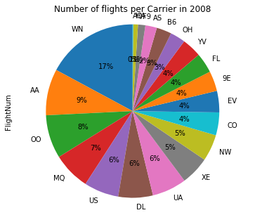

```python
df_2008.groupby('UniqueCarrier')['FlightNum'].count().sort_values(ascending = False).plot(kind='pie',
                                                                figsize=(6, 5),
                                                                autopct='%1.0f%%',
                                                                startangle=90
                                                                )

plt.title('Number of flights per Carrier in 2008')
plt.axis('equal')

plt.show()
```

## On-time arrival performance by Carrier and month

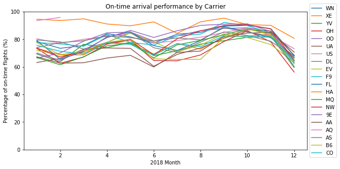

```python
plt.figure(figsize = [10, 5])
for i in Carrier_list:
    plt.plot(df_carrier_ontime[df_carrier_ontime['UniqueCarrier'] == i]['Month'],
             df_carrier_ontime[df_carrier_ontime['UniqueCarrier'] == i]['percent_on_time'],
            label = i)

plt.title('On-time arrival performance by Carrier')
plt.ylabel('Percentage of on-time flights (%)')
plt.xlabel('2018 Month')
plt.ylim(ymin = 0,
         ymax = 100)
plt.legend(loc='center left', bbox_to_anchor=(1, 0.5))
plt.show()
```

## On-time arrival performance by Carrier

Regarding only by carrier, the percent of on-time flghts is more than 70% for every carrier. The better carrier on this criteria is AQ following by HA.

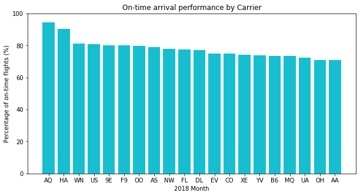

```python
plt.figure(figsize = [10, 5])
for i in Carrier_list:
    plt.bar(df_ontime['UniqueCarrier'],
            df_ontime['percent_on_time'])

plt.title('On-time arrival performance by Carrier')
plt.ylabel('Percentage of on-time flights (%)')
plt.xlabel('2018 Month')
plt.ylim(ymin = 0,
         ymax = 100)
plt.show()
```

## On-time arrival performance by origin airport

More than 98% of flights in INL and WYS airports are on time.

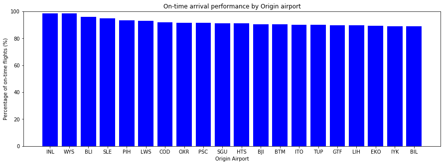

```python
plt.figure(figsize = [15, 5])
for i in Carrier_list:
    plt.bar(df_ontime_origin['Origin'],
            df_ontime_origin['percent_on_time'],
           color = 'blue')

plt.title('On-time arrival performance by Origin airport')
plt.ylabel('Percentage of on-time flights (%)')
plt.xlabel('Origin Airport')
plt.ylim(ymin = 0,
         ymax = 100)
plt.show()
```

## On-time arrival performance by destination airport

Almost all flights in TUP airport are on time. It is not the same situation in CPR or HLN where there is around 85% flights on-time.

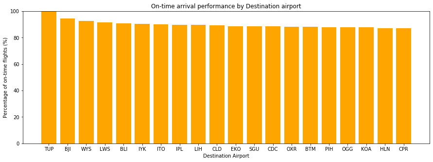

```python
plt.figure(figsize = [15, 5])
for i in Carrier_list:
    plt.bar(df_ontime_dest['Dest'],
            df_ontime_dest['percent_on_time'],
           color = 'orange')

plt.title('On-time arrival performance by Destination airport')
plt.ylabel('Percentage of on-time flights (%)')
plt.xlabel('Destination Airport')
plt.ylim(ymin = 0,
         ymax = 100)
plt.show()
```

## Correlation between Arrival and Departure Delay

There is a high correlation between arrival and departure delay : a departure on-time will conducted to an arrival on-time.

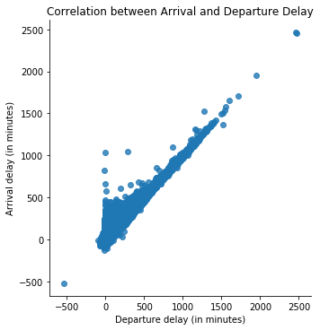

```python
sns.lmplot(data=df_2008,
           x='DepDelay',
           y='ArrDelay',
           fit_reg=False)

plt.title('Correlation between Arrival and Departure Delay')
plt.xlabel('Departure delay (in minutes)')
plt.ylabel('Arrival delay (in minutes)')

plt.show()
```

## Reason of delay

The main reason for delay is late aircraft, followed by NAS and then Carrier. Security seems to be a very poor reason of delay.

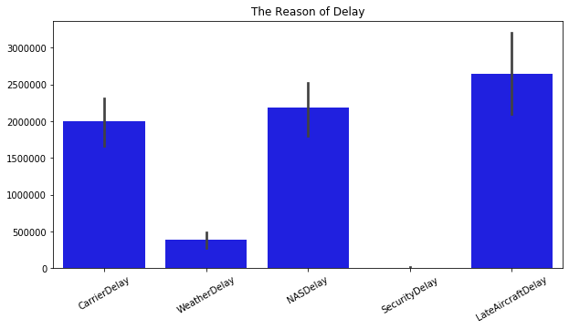

```python
plt.figure(figsize=(10,5))

sns.barplot(data= df_2008.groupby('Month')[['CarrierDelay', 'WeatherDelay', 'NASDelay', 'SecurityDelay', 'LateAircraftDelay']].sum(),
           color = 'blue')

plt.title('The Reason of Delay')
plt.xticks(rotation='30')

plt.show()
```

## Cancellation reason

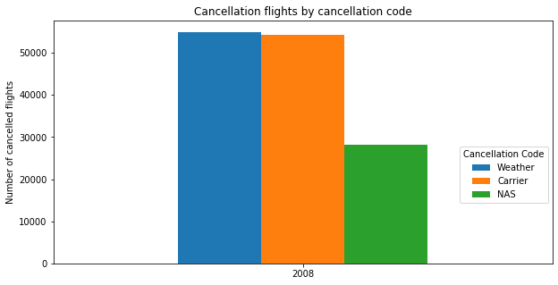

```python
df_cancel.plot(kind = 'bar',
                sort_columns= 'CancellationCode',
                figsize=(10,5));
plt.legend(bbox_to_anchor=(1, 0.5),
           title = 'Cancellation Code')
plt.xticks(rotation=0)
plt.xlabel('')
plt.ylabel('Number of cancelled flights')
plt.title('Cancellation flights by cancellation code');

plt.show()
```

# Conclusion

In 2008, most than 7 million flights were planned. Almost 23% were delayed and 2% were cancelled. These 23% of delayed flights corresponds mainly to Late Aircraft Delay, NAS delay and Carrier Delay. Concerning the 2% of cancelled flights, there are mainly due to Weather and Carrier.